# Markets and Trading

Kevin Crotty  
BUSI 448: Investments

## Where are we?

**Last time**:

- Arbitrage

**Today**:

- Market structure
- Liquidity
- Adverse Selection

## Primary versus secondary markets

- Primary: an issuing institution is interacting with the market and accessing capital
- Secondary: trades are generally between any interested party

## Types of Markets

- Limit order book trading (continuous)
- Over-the-counter markets (dealer markets)
- Call markets

## Limit order book markets

- Continuous markets: trades can occur at any time when the market is open
- A **limit order** is an order with a price specified.
  - Buy at price of x or less
  - Sell at price of x or more
  - If not immediately executable, it goes into the “book.”
  - Has *execution* risk
- **Market orders** are orders to trade “at market,” taking whatever price is available.
  - Has *price* risk
- Your broker is required to route your executable order to the venue offering the best price.

Examples:

- Equity market intraday trading (NYSE, Nasdaq)
- Futures, options, FX markets

## Bid-ask spread

- The price on a limit sell order is called an ask or offer price.
- The price on a limit buy order is called a bid.
- The best (lowest) ask and best (highest) bid are called the inside quotes.
- The difference between the best ask and the best bid is called the bid-ask spread or bid-offer spread.

## Example of a limit order book

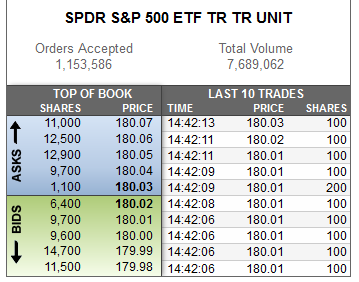

The bid-ask spread is 180.02–180.03.

## Order priority

- Most trading venues use *price priority* to rank orders
  - Highest-priced buy orders get preference.
  - Lowest-priced sell orders get preference.
- Next is usually *time priority*
  - Orders placed first get preference.
- Concerns about execution risk lead to traders attempting to jump to the front of the line.

## Over-the-counter markets (dealer markets)

- Dealers and other traders are linked electronically.
- Characterized by search costs of finding a suitable counterparty

Examples include secondary trading in:

- corporate bonds
- government bonds
- money market instruments
- some equities

## Call markets

- Markets for some assets are called periodically, at which point trade occurs.
- The price-setting mechanism is some form of an auction.

Examples:

- Gov’t bond auctions
- open/close for equity markets
- intraday for low-activity equities (sporadic call auctions)

## Institutional trading

- Mutual funds etc. typically execute trades over several days, trading a small amount at a time, to minimize the price impacts of their trades.
  - Brokers provide algorithms optimized to minimize price impacts.
- High frequency trading (HFT) is a different kind of automated trading.
  - HFTs look for opportunities that may only exist for only a millisecond and only earn a penny a share or less.

## Internalization and payment for order flow

- Retail orders are primarily executed on Alternative Trading Systems rather than the limit order book.
- Your broker/dealer may execute your order itself, to earn the bid-ask spread.
- Or your broker may send your order to another institution in exchange for a “kickback” of part of the spread.
- You are nevertheless supposed to get the National Best Bid or Offer (NBBO).

## Transparency

- **Transparency**: what and when information is available
- **Pre-trade** transparency
  - indicative orders visible (prices & quantities)
- **Post-trade** transparency
  - trade information visible (prices & quantities)

## Transparency across markets

Different markets provide differing levels of transparency.

- Some markets only display top of the book (best bid/offer or top N)
- Others show entire LOB
- Equity and options markets are fairly transparent
- Corporate bond markets are less transparent, but have become more so.

## Knowledge of most recent pricing is valuable:

From 2022 NYSE Proprietary Market Data Pricing Guide:

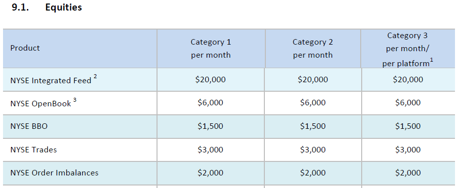

## Liquidity

**Liquidity** is the ease with which one can convert an asset into cash.

- Can you sell the asset quickly?
- Can you sell it with little loss in value?

Examples:

- Treasury bills and index ETFs are liquid assets
- Corporate bonds, private equity, and real estate are illiquid assets

# For next time: Leverage + Margin

[figure not shown]

[figure not shown]

BUSI 448